# Exploring convergence issues

Ben Bolker

17:15 01 August 2016

One of the major issues in recent releases of `lme4` (1.1-6) forward has been the increased rate of model fits that are reported not to converge. Possibly contrary to popular belief, this increased rate of reported problems is **not** due to greater instability or other problems in the fitting algorithm itself; the algorithms themselves and their default settings have changed only slightly in recent releases (see the [lme4 NEWS file](https://github.com/lme4/lme4/blob/master/inst/NEWS.Rd)). Rather, we introduced new convergence checks, so lots of models that *seemed* to fit with previous versions now report convergence issues (but in fact are fitting just as well, or as poorly, as before).

Along with the convergence tests, however, have come some false-positive warnings. These were particularly bad in 1.1-6; version 1.1-7 improved things considerably by testing the *scaled* gradient (i.e., the solution of $\boldsymbol{H}\boldsymbol{s} = \boldsymbol{g}$, where $\boldsymbol{H}$ is the estimated Hessian at the MLE, $\boldsymbol{g}$ is the absolute gradient, and $\boldsymbol{s}$ is the scaled gradient). To a first approximation, one can think of the scaled gradient as measuring the expected change in the log-likelihood over a scale of one standard error of parameter change, rather than on the scale of the original parameter. A further change ([22 October 2014](https://github.com/lme4/lme4/commit/60d73d2023c380c99759d159caaf104aaf5649c8), in Github/1.1-8 version but not yet in the [CRAN version](http://cran.r-project.org/web/packages/lme4/index.html), dated 19 July 2014) changed the test to find the maximum absolute value of the *minimum* of absolute and scaled gradient, to handle situations where the estimated likelihood surface was very flat (poorly determined parameters/large standard errors) so that the scaled gradient would be very large.

The examples below explore the dependence of the scaled gradient and computed Hessians for relatively well-behaved data sets as a function of (simulated) data set size. This does not tell us exactly where we should set the threshold for convergence warnings, but it does indicate that

1. our thresholds are probably too strict for large data sets [for well-behaved examples below where we think we are getting the correct answers, our current rules would report convergence failures].
2. the thresholds might be scaled to sample size, but as explored below this is difficult. If we deprecated use of `nlminb` for large problems, an overall scaled tolerance of 0.01 might be appropriate …
3. we should switch from our current, fast-but-sloppy finite difference calculation of Hessians to the more accurate but slower Richardson extrapolation calculation implemented in the `numDeriv` package for large sample sizes.

```r
library("lme4")
library("grid")
library("ggplot2")
## preferred (cosmetic) settings
theme_set(theme_bw()+theme(panel.margin=unit(0,"lines")))
library("gridExtra")
library("scales") ## for squish()
## with apologies for Hadleyverse 2 ...
library("tidyr")
library("dplyr")
```

Get data:

```r
load("penicillin_conv.RData")
id_vars <- c("data","optimizer","log10size","rep")
data_vars <- setdiff(names(res),id_vars)
```

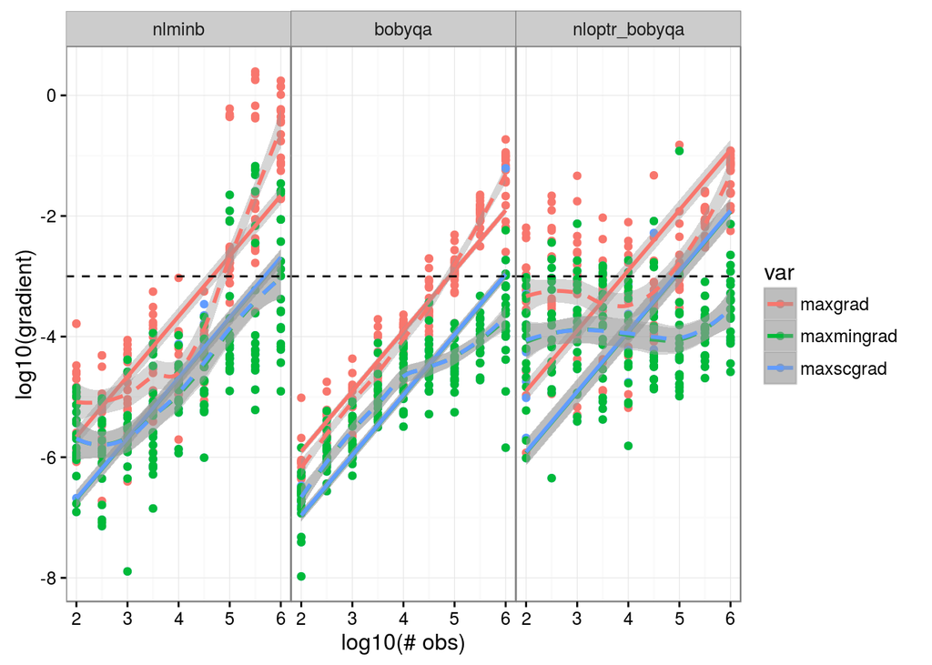

- the straight lines are the best-fit slope-1 lines (i.e. gradient strictly proportional to sample size); the dashed lines are the usual loess fits
- the horizontal dashed line shows our current checking cutoff of 0.001 The `nloptr_bobyqa` results are using a slightly different implementation of the same algorithm used in the built-in (`minqa`-packaged) BOBYQA, but using looser tolerance settings, so they perform worse (in terms of gradients) at small sample sizes, but compare reasonably well to other methods
- the scaled-gradient points are largely invisible because in this case, the scaled gradient is almost always smaller than the absolute gradient, so the `maxmingrad` point (which is drawn later) covers the scaled-gradient point except in a few cases.
- As explored in more detail below, the highest points for the `nlminb` optimizer (i.e. the cases where the absolute gradient goes up to about 1) probably do represent problematic fits.
- I use log10 of the gradients throughout below, even where I forget to label them as such (perhaps obvious because they’re negative …)

Proportion of bad fits under current rules:

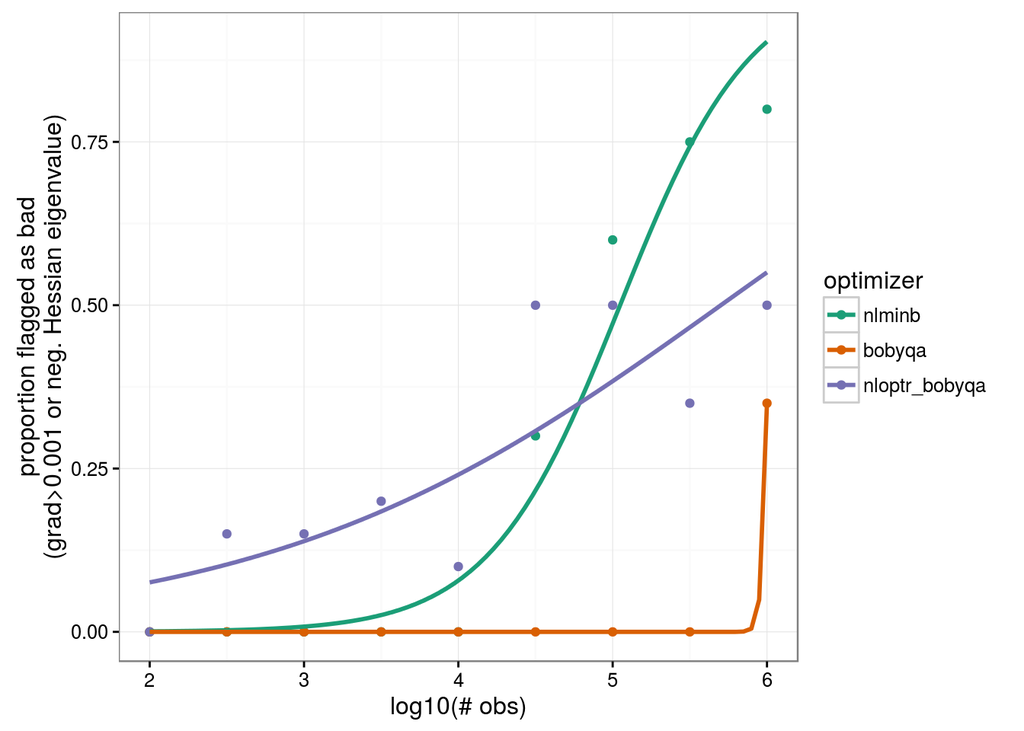

Behaviour of estimated minimum eigenvalues (top row, unmodified: bottom row, clamped to (0.5,5)):

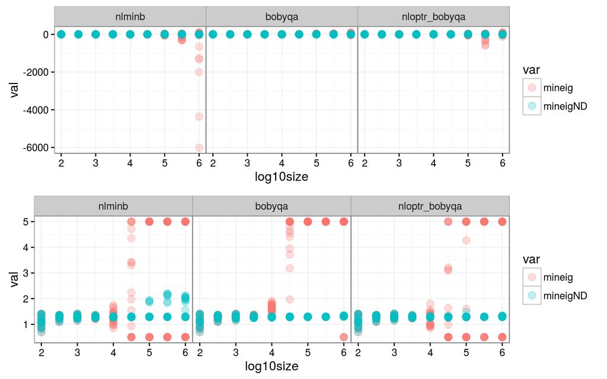

Timing:

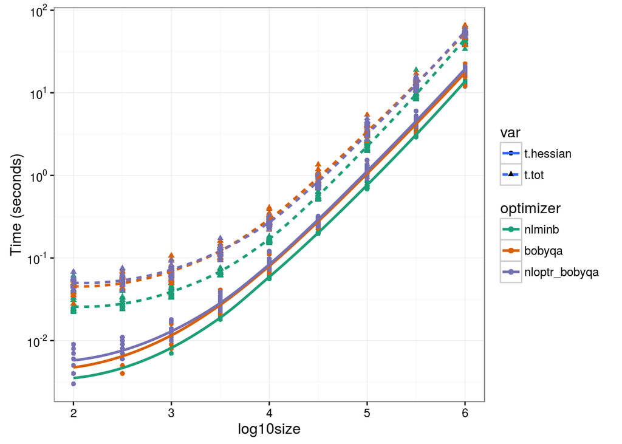

Actual parameter estimates:

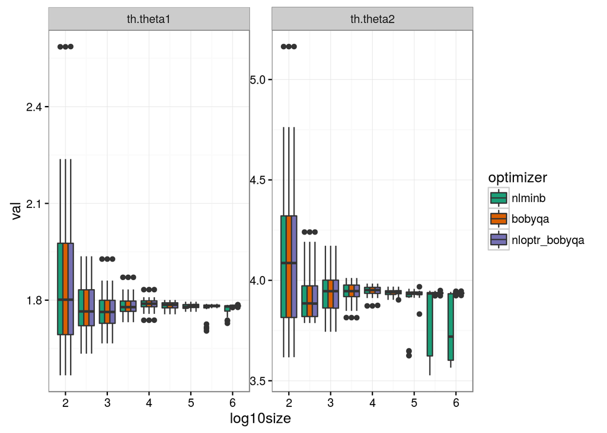

(Would like outlier colours to match, but too much trouble; `outlier.colour=NULL` doesn’t work for some reason.) This shows that `nlminb` becomes unreliable at large sample sizes (don’t know how these incorrect estimates match up with convergence tests).

What if we try to figure out which estimates actually *are* bad (as judged by their difference from a consensus estimate), rather than just seeing which ones fail the convergence tests? Compute proportion of fit/parameter combinations where all but estimates from all but one optimizer agree to within 1% (relative standard deviation <1%) *and* the remaining estimate differs by >1%:

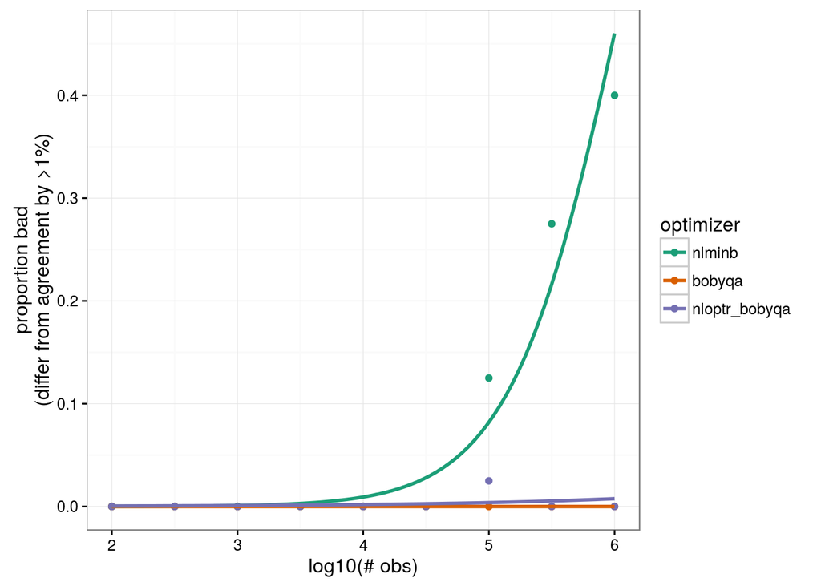

What if we compare the max gradient with the size of the error (= mean difference of parameters from consensus)?

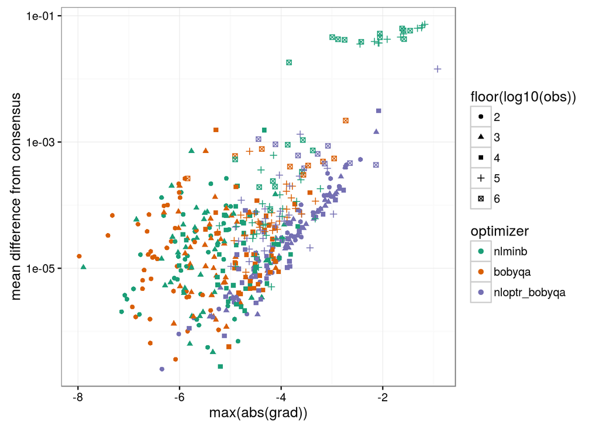

Unfortunately there’s no threshold we can draw with respect to the max-gradient (i.e., on the horizontal axis) that will separate “bad” (say >1%) results.

If we scale the gradient by the size (i.e. $\log(\textrm{grad})+\log(\textrm{nobs})$, equivalent to scaling the cutoff by the number of observations) we do a little better, but still can’t draw a clean cutoff:

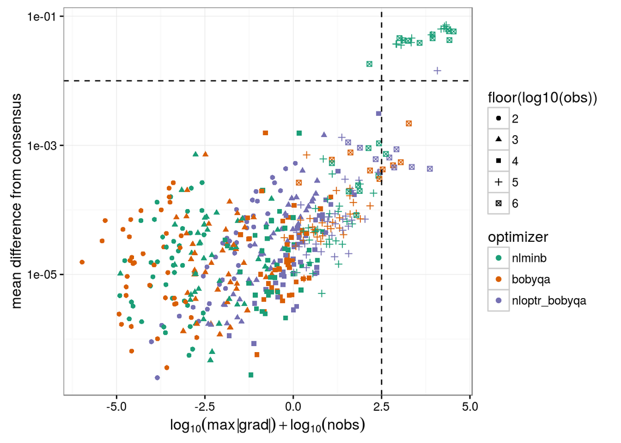

For example, if we required $\log_{10}(\max(|\textrm{grad}|))+\log_{10}(\textrm{nobs})<2.5$, we would get most (but not all) of the cases with error >1%, but we would still catch a variety of cases (with large data sets) with error <0.1% …

If we turn off Hessian computations for large data we don’t have access to the scaled gradient; then we could set the gradient criterion to 0.5 (for this *particular* example; presumably it would be a bit different for other cases …)

```r
red3 <- m %>% filter(var=="maxgrad") %>%
    select(-c(data,var)) %>%
        rename(grad=val)
bad_ests4 <- full_join(bad_ests2,red3) %>% ungroup() %>%
    mutate(sfac=factor(floor(log10size)))
```

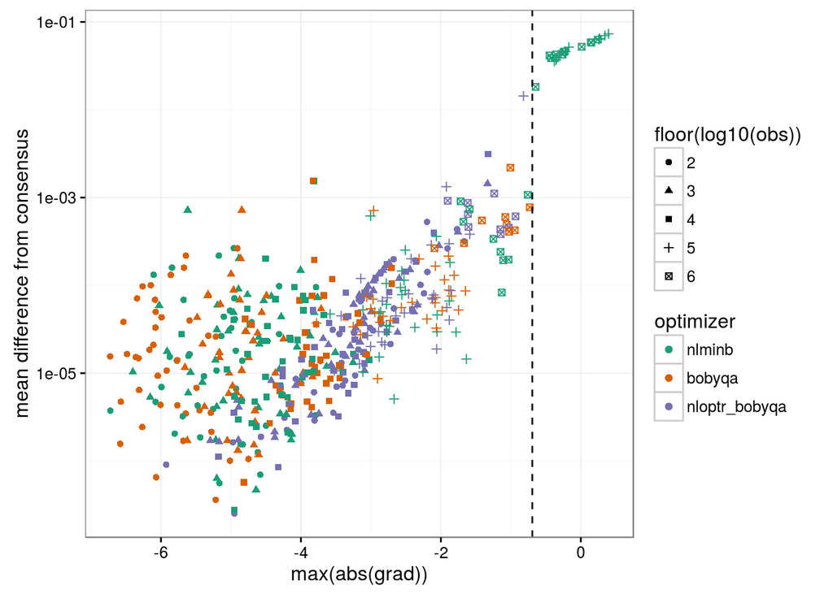

```r
gg_bad3 %+% bad_ests4+ geom_vline(xintercept=log(0.5),lty=2)
```

### To do

- Other data sets? Less well-behaved examples? `glmer` examples?
- Simulated data?
- Will it help to pick out parameters one at a time rather than taking mean difference from consensus (e.g. if badness is not spread evenly across parameters)? Is there some other metric we can look at to detect bad fits?
- Other ways to detect bad fits, e.g. restarting rather than just trying to detect lack of/difference from consensus?